# Exploratory Data Analysis with White Wine Dataset

Qi Zhao

2018-03-01

The report performs the exploratory data analysis on the white wine dataset which records the variables of the Portuguese “Vinho Verde” wine. We are provided with some objective tests results(e.g. PH values) and the quality of the white wine, graded by the experts. What we are interested in is the factors that influence the taste of the wine. There is no missing data in this dataset which makes it easier for us to explore.

# 1. Univariate Plots Section

First of all, let’s look at the shape of the white wine dataset.

```
## [1] 4898   12
```

The white wine dataset contain 12 variables and 4898 observations. The 12 variables are: fixed.acidity, volatile.acidity, citric.acid, residual.sugar, chlorides, free.sulfur.dioxide, total.sulfur.dioxide, density, pH, sulphates, alcohol, quality.

In this section, we are going to use univariate plots to analyze the data. What’s their distribution? Do we need to apply transformation to make the data look more “normal”? Before all that, let’s take a look at the variables’ meaning and some basic statistics.

The first thing we need to understand is that the quality(our response variable) is scored between between 0 (very bad) and 10 (very excellent).

The table below shows the minimum, mean, median, maximum and variance of all variables, which gives us a basic idea of the data.

|  | minimum | median | mean | maximum | variance |
| --- | --- | --- | --- | --- | --- |
| fixed.acidity | 3.80000 | 6.80000 | 6.8547877 | 14.20000 | 0.7121136 |
| volatile.acidity | 0.08000 | 0.26000 | 0.2782411 | 1.10000 | 0.0101595 |
| citric.acid | 0.00000 | 0.32000 | 0.3341915 | 1.66000 | 0.0146458 |
| residual.sugar | 0.60000 | 5.20000 | 6.3914149 | 65.80000 | 25.7257702 |
| chlorides | 0.00900 | 0.04300 | 0.0457724 | 0.34600 | 0.0004773 |
| free.sulfur.dioxide | 2.00000 | 34.00000 | 35.3080849 | 289.00000 | 289.2427200 |
| total.sulfur.dioxide | 9.00000 | 134.00000 | 138.3606574 | 440.00000 | 1806.0854908 |
| density | 0.98711 | 0.99374 | 0.9940274 | 1.03898 | 0.0000089 |
| pH | 2.72000 | 3.18000 | 3.1882666 | 3.82000 | 0.0228012 |
| sulphates | 0.22000 | 0.47000 | 0.4898469 | 1.08000 | 0.0130247 |
| alcohol | 8.00000 | 10.40000 | 10.5142670 | 14.20000 | 1.5144270 |
| quality | 3.00000 | 6.00000 | 5.8779094 | 9.00000 | 0.7843557 |

From the variables, I noticed that there are “free sulfur dioxide” and “total sulfur dioxide” which are obviously correlated since the free sulfur dioxide is a part(probably a big part) of the total sulfur dioxide. Therefore, I create a new variable called “nonfree.sulfur.dioxide” which equals the difference of total and free sulfur dioxide.

```r
wine$total.sulfur.dioxide <- wine$total.sulfur.dioxide - wine$free.sulfur.dioxide
colnames(wine)[7] <- "nonfree.sulfur.dioxide"
names <- colnames(wine)
```

## 1.1 Box Plots

First of all, let’s look at the boxplots.

[interactive chart not shown]

- As we can see, most qualities are in 5,6 and 7 and there is no data in 1,2 and 10.

```
##
##    3    4    5    6    7    8    9
##   20  163 1457 2198  880  175    5
```

- Fixed Acidity, Volatile Acidity, Critic Acid, Chlorides, Free Sulfur Dioxide, pH and Sulphates have many outliers. Besides, most outliers are greater than the majority.
- The residual sugar is obviously not normal distributed even after the outlier removal.

## 1.2 Outlier Detection

First let’s see the frequency of the different qualities. We observed that there are only 5 cases out of 4898 row that scored 9.

| Var1 | Freq |
| --- | --- |
| 3 | 20 |
| 4 | 163 |
| 5 | 1457 |
| 6 | 2198 |
| 7 | 880 |
| 8 | 175 |
| 9 | 5 |

Since we want to learn about all the qualities of the white wine from 3 to 9, we do not want those 5 cases to be seen as outliers because of their high grade. Thus we should exclude the quality variable when eliminating the outliers.

```
## [1] 10
```

```r
wine <- wine[-outindex,]
```

## 1.3 Histgrams

Now we have removed all the outliers and we can observe the histgrams. Below are the 12 histgram plots of 12 variables.

[interactive chart not shown]

Still, as we have seen before, the residual sugar needs to be transformed because it is heavily right-skewed. Thus, I decide to perform the log transformation on this variable.

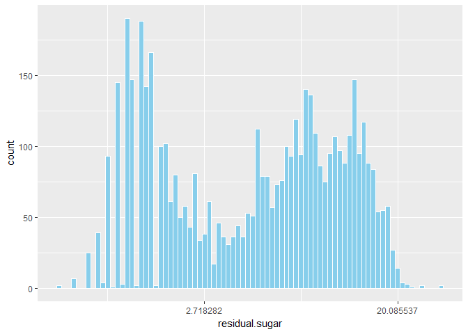

From the plot, we can see clearly that this is a Bimodal Distribution with 2 peaks, which is a mixture of data from 2 normal distributions.

# 2.Univariate Analysis Section

- I created a new variable called “nonfree.sulfur.dioxide” due to the obvious dependency between “free.sulfur.dioxide” and “total.sulfur.dioxide”
- The most important variable is our target variable: the quality of the wine. There are totally 7 qualities that has appeared in this dataset: 3,4,5,6,7,8 and 9. About 92.5% data falls in 5,6,7.
- Many data are right-skewed. I performed a log-transformation on the “residual.sugar” variable.
- Right now, there’s no clear information about the importance of each variables except the quality.

# 3.Bivariate Plots Section

In this section, we are going to explore the relations between each variable. Especially the difference between each qualities.

## 3.1 Mean in Each Group

First of all, let’s look at the mean of each variable within each group.

| quality | 3.00 | 4.00 | 5.00 | 6.00 | 7.00 | 8.00 | 9.00 |
| --- | --- | --- | --- | --- | --- | --- | --- |
| fixed.acidity | 7.63 | 7.14 | 6.93 | 6.83 | 6.74 | 6.66 | 7.42 |
| volatile.acidity | 0.33 | 0.38 | 0.30 | 0.26 | 0.26 | 0.28 | 0.30 |
| citric.acid | 0.34 | 0.31 | 0.34 | 0.34 | 0.33 | 0.33 | 0.39 |
| residual.sugar | 6.08 | 4.63 | 7.34 | 6.42 | 5.19 | 5.67 | 4.12 |
| chlorides | 0.05 | 0.05 | 0.05 | 0.05 | 0.04 | 0.04 | 0.03 |
| free.sulfur.dioxide | 41.22 | 23.45 | 36.40 | 35.67 | 34.10 | 36.72 | 33.40 |
| nonfree.sulfur.dioxide | 103.53 | 101.93 | 114.47 | 101.37 | 90.99 | 89.45 | 82.60 |
| density | 0.99 | 0.99 | 1.00 | 0.99 | 0.99 | 0.99 | 0.99 |
| pH | 3.18 | 3.18 | 3.17 | 3.19 | 3.21 | 3.22 | 3.31 |
| sulphates | 0.46 | 0.48 | 0.48 | 0.49 | 0.50 | 0.49 | 0.47 |
| alcohol | 10.30 | 10.14 | 9.81 | 10.57 | 11.36 | 11.64 | 12.18 |

However, in most cases, the extreme value may lead to a extremely great result or a very bad one. For example, the mean value of fixed acidity is gradually decrease from quality 3 to quality 8. However, in quality 9, it suddenly changed to a very high value.

That means for most values, it’s not simply “the more the better” or “the less the better”.

## 3.2 Correlation Plot

Below is a Pearson correlation Plot of all 12 variables. The darker square means there are stronger correlation between two variables.

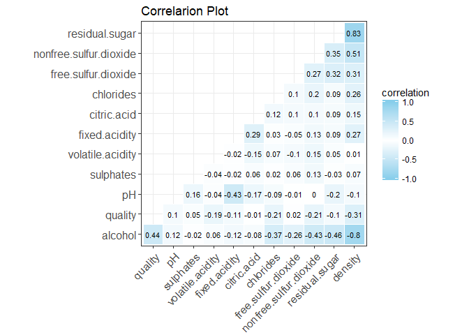

From the plot we can see some strong correlation pairs.

## 3.3 Scatter Plot

First, let’s look at some of the interesting scatter plots. The different colors represent different qualities.

[interactive chart not shown]

# 4. Bivariate Analysis

From the scatter plots, just like what the correlation matrix has suggested, we’ve found some linear relations between selected variables. Thus we do a regression analysis between them.

```r
model <- list()
for (i in 1:4){model[[i]] <- lm(wine[[y[i]]] ~ wine[[x[i]]])}
```

## 4.1

In the first plot, we can see clearly that the amount of sugar remaining after fermentation stops has a strong relation with the density. What’s more, it seems that we can find two straight lines to separate the three different color of quality 5,6 and 7. It seems that the lower density and higher residual sugar can lead to better quality.(We will have to explore this separation in next section.)

Based on the $R^2$ the residual.sugar can explain 70% variance in density.

```r
summary(model[[1]])
```

```
##
## Call:
## lm(formula = wine[[y[i]]] ~ wine[[x[i]]])
##
## Residuals:
##        Min         1Q     Median         3Q        Max
## -0.0055566 -0.0011110  0.0001936  0.0011567  0.0060162
##
## Coefficients:
##               Estimate Std. Error t value Pr(>|t|)
## (Intercept)  9.909e-01  3.737e-05 26517.8   <2e-16 ***
## wine[[x[i]]] 4.869e-04  4.609e-06   105.7   <2e-16 ***
## ---
## Signif. codes:  0 '***' 0.001 '**' 0.01 '*' 0.05 '.' 0.1 ' ' 1
##
## Residual standard error: 0.001612 on 4886 degrees of freedom
## Multiple R-squared:  0.6955, Adjusted R-squared:  0.6955
## F-statistic: 1.116e+04 on 1 and 4886 DF,  p-value: < 2.2e-16
```

## 4.2

From the second plot, we see that there is a clear negative correlation between alcohol and density. This matches our intuition.

Admittedly, in most cases we cannot assume the cause and result between variables. However, as we all know, the density of the alcohol is smaller than the density of water. Thus, the increasing percent alcohol content of the wine can definately lead to a lower density.

```r
summary(model[[2]])
```

```
##
## Call:
## lm(formula = wine[[y[i]]] ~ wine[[x[i]]])
##
## Residuals:
##        Min         1Q     Median         3Q        Max
## -0.0054852 -0.0012290 -0.0001371  0.0011664  0.0130186
##
## Coefficients:
##                Estimate Std. Error t value Pr(>|t|)
## (Intercept)   1.014e+00  2.147e-04 4722.70   <2e-16 ***
## wine[[x[i]]] -1.905e-03  2.029e-05  -93.89   <2e-16 ***
## ---
## Signif. codes:  0 '***' 0.001 '**' 0.01 '*' 0.05 '.' 0.1 ' ' 1
##
## Residual standard error: 0.001744 on 4886 degrees of freedom
## Multiple R-squared:  0.6434, Adjusted R-squared:  0.6433
## F-statistic:  8816 on 1 and 4886 DF,  p-value: < 2.2e-16
```

## 4.3

From the plot, it seems that there may be a positive correlation between fixed acidity and citric acid. The linear regression model does confirm my guess. With a P-value that is almost 0, there are definately some positive relation between these two variables.

```r
summary(model[[3]])
```

```
##
## Call:
## lm(formula = wine[[y[i]]] ~ wine[[x[i]]])
##
## Residuals:
##      Min       1Q   Median       3Q      Max
## -0.34830 -0.06756 -0.01682  0.04755  0.86511
##
## Coefficients:
##              Estimate Std. Error t value Pr(>|t|)
## (Intercept)  0.049668   0.013495    3.68 0.000235 ***
## wine[[x[i]]] 0.041477   0.001955   21.22  < 2e-16 ***
## ---
## Signif. codes:  0 '***' 0.001 '**' 0.01 '*' 0.05 '.' 0.1 ' ' 1
##
## Residual standard error: 0.1144 on 4886 degrees of freedom
## Multiple R-squared:  0.08439,    Adjusted R-squared:  0.0842
## F-statistic: 450.3 on 1 and 4886 DF,  p-value: < 2.2e-16
```

## 4.4

There is a clearly negative correlation between fixed acidity and the pH value.

```r
summary(model[[4]])
```

```
##
## Call:
## lm(formula = wine[[y[i]]] ~ wine[[x[i]]])
##
## Residuals:
##      Min       1Q   Median       3Q      Max
## -0.38445 -0.08987 -0.00987  0.07896  0.58699
##
## Coefficients:
##               Estimate Std. Error t value Pr(>|t|)
## (Intercept)   3.716558   0.016077  231.17   <2e-16 ***
## wine[[x[i]]] -0.077118   0.002329  -33.12   <2e-16 ***
## ---
## Signif. codes:  0 '***' 0.001 '**' 0.01 '*' 0.05 '.' 0.1 ' ' 1
##
## Residual standard error: 0.1363 on 4886 degrees of freedom
## Multiple R-squared:  0.1833, Adjusted R-squared:  0.1832
## F-statistic:  1097 on 1 and 4886 DF,  p-value: < 2.2e-16
```

# 5.Multivariate Plots Section

From last section we have observed that residual sugar, alcohol, density and pH may have strong effect on the taste of the wine. Now let’s take a deep look at it.

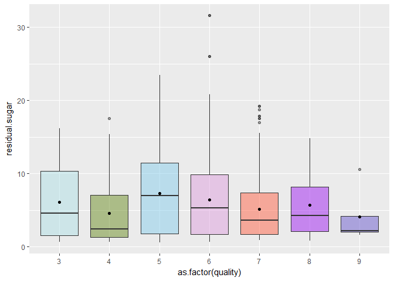

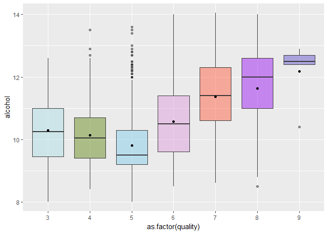

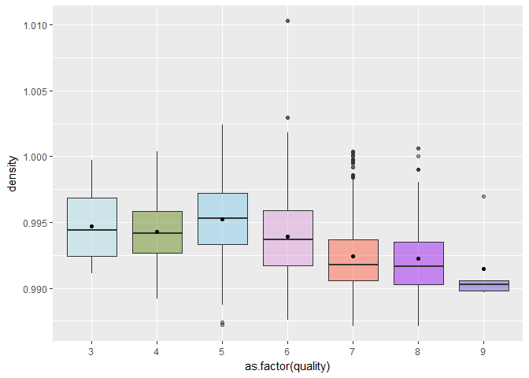

# 6.Multivariate Analysis

From the 3 plots above, we can see that there are relationships between them and the quality. So we can build a linear regression model to predict the quality of the wine.

```r
model.new <- lm(quality~alcohol+density+ residual.sugar, data=wine)
summary(model.new)
```

```
##
## Call:
## lm(formula = quality ~ alcohol + density + residual.sugar, data = wine)
##
## Residuals:
##     Min      1Q  Median      3Q     Max
## -3.5182 -0.5371 -0.0096  0.4724  3.1893
##
## Coefficients:
##                  Estimate Std. Error t value Pr(>|t|)
## (Intercept)     92.447987  13.487995   6.854 8.07e-12 ***
## alcohol          0.243564   0.019799  12.302  < 2e-16 ***
## density        -90.011804  13.419353  -6.708 2.20e-11 ***
## residual.sugar   0.053910   0.005268  10.234  < 2e-16 ***
## ---
## Signif. codes:  0 '***' 0.001 '**' 0.01 '*' 0.05 '.' 0.1 ' ' 1
##
## Residual standard error: 0.7848 on 4884 degrees of freedom
## Multiple R-squared:  0.2118, Adjusted R-squared:  0.2113
## F-statistic: 437.4 on 3 and 4884 DF,  p-value: < 2.2e-16
```

Unfortunately, this is not a very satisfying result, the $R^2$ is only 0.2 meaning only 20% of the variance of the quality can be explained by the 3 variables.

# 7.Final Plots & Summary

There are three final plots that I have chosen which can show the most interesting things that I have found.

## 7.1 First Plot

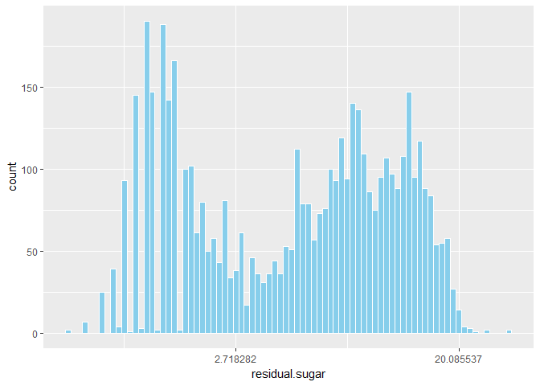

The distribution of the log transformation of residual sugar turns out to be bimodal. From later analysis we find out that the mean residual sugar of the best and worst quality are relatively low and the those in the middle tend to have higher residual sugar. This indicates that the sweeter taste of white wine may be a “safe card”.

## 7.2 Second Plot

[interactive chart not shown]

## 7.3 Third Plot

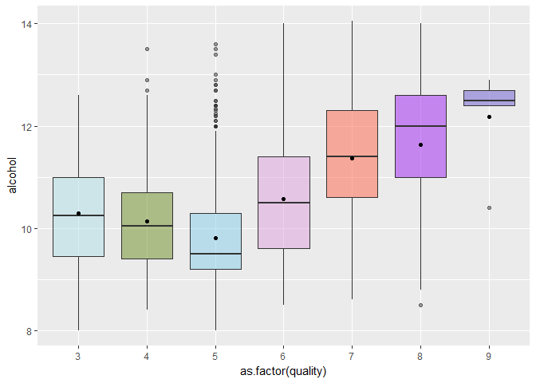

The third plot is the boxplot of the alcohol within each group. Apparently the quality of the white wine improved significantly as the alcohol content becomes higher.

## 8. Reflection

In this report, I first explored each variable individually. Then I tried to capture the relationships between the variables. In the end, I try to find the factors that have the most influence on the wine quality.

Besides, I also have made an interactive presentation file using R shiny for readers to explore the distribution of each variables and the correlation between varibles by themselves. Here’s the link: https://louischoki.shinyapps.io/QiPresen/#1.